# Coursera > JHU Data Science Specialization > Course 08: Practical Machine Learning > Course Project: Prediction of Human Activities

Dan Charlson

2023-07-27

## Prediction of Human Activities: Dumbbell Weightlifting

#### Coursera > JHU Data Science Specialization > Course 08: Practical Machine Learning > Course Project

Dan Charlson *coursera@dancha.com* July 27, 2023

## Executive Summary

In this Practical Machine Learning course, we have surveyed a wide range of machine learning techniques. This project involves applying a number of those techniques on a data set, comparing their relative levels of accuracy, and choosing a “best” one. Specifically, we will train models on some Human Activity data (weightlifting). *This is basically a supervised classification exercise*. The focus in that original Human Activity project was on technique, not reps or weight. A “right technique” was designated, with four “wrong techniques.” The goal will be to *best identify (most accurately predict) the activities in the Test data set exhibiting the* **correct *technique***.

I will apply these methods:

- Decision Trees / Recursive Partitioning - *rpart*
- Random Forest - *rf*
- Gradient Boosted Trees - *gbm*
- Model-based Prediction: Linear Discriminant Analysis (LDA) - *lda*

Since both Training and Test Data sets were provided, I will further sub-divide Training into Training and Validation sets. I will apply the technique of **Cross-Validation** (five-fold) to better estimate accuracy on the eventual Test Data set.

Of these, *Random Forests* had the highest accuracy on the Training data set. (That said, *Gradient Boosted Forests* was less than half a percentage point less accurate.)

To complete this course, in addition to the creation, publish, and peer review of this report, I will apply my top method/model against a specified Test Data Set, and report its findings via the Coursera Quiz format (separately from this report).

I did so in the course of creating this report, and am pleased to report I attained 100% accuracy on the Quiz.

## About the Assignment

The following text taken verbatim from the Week 4 > Course Project page:

*One thing that people regularly do is quantify how **much** of a particular activity they do, but they rarely quantify **how well they do it**. In this project, your goal will be to use data from accelerometers on the belt, forearm, arm, and dumbbell of 6 participants. The goal of your project is to predict the manner in which they did the exercise. This is the “classe” variable in the training set. You may use any of the other variables to predict with. **You should create a report describing how you built your model, how you used cross validation, what you think the expected out of sample error is, and why you made the choices you did**.*

## About the Data

The data comes from a project and paper called “Wearable Computing: Accelerometers’ Data Classification of Body Postures and Movements,” by Ugulino, W.; Cardador, D.; Vega, K.; Velloso, E.; Milidiu, R.; Fuks, H. The original website is no longer available, but can be found on the Internet Archive:

http://web.archive.org/web/20161224072740/http:/groupware.les.inf.puc-rio.br/har

### Description

“Six young health participants were asked to perform one set of 10 repetitions of the Unilateral Dumbbell Biceps Curl in five different fashions: exactly according to the specification (Class A), throwing the elbows to the front (Class B), lifting the dumbbell only halfway (Class C), lowering the dumbbell only halfway (Class D) and throwing the hips to the front (Class E).”

## Data Processing and Summary

The data set for this Course Project was provided in the Assignment:

*The training data for this project are available here:*

https://d396qusza40orc.cloudfront.net/predmachlearn/pml-training.csv

*The test data are available here:*

https://d396qusza40orc.cloudfront.net/predmachlearn/pml-testing.csv

### Load any required libraries

```r
# Important note: please perform install.packages ahead of time as required
library(caret)
```

```r
# FYI: as necessary, this will load dependencies: ggplot2 and lattice
library(rattle)
```

### Load the data

```r
setwd("/Users/dancharlson/Dropbox/Courses/Coursera/01 Data Science Specalization (JHU)/08_PracticalMachineLearning/CourseProject")
training_data <- read.csv("pml-training.csv", na.strings = c("NA", ""))
test_data <- read.csv("pml-testing.csv", na.strings = c("NA", ""))
```

### Basic Exploratory Data Analysis

I will start with some basic techniques.

```r
dim(training_data)
```

```
## [1] 19622   160
```

```r
dim(test_data)
```

```
## [1]  20 160
```

As expected, they share the same number of columns, but differ vastly in the number of observations.

Now for a little more detail:

```r
# check out the data
str(training_data)
```

```
## 'data.frame':    19622 obs. of  160 variables:
##  $ X                       : int  1 2 3 4 5 6 7 8 9 10 ...
##  $ user_name               : chr  "carlitos" "carlitos" "carlitos" "carlitos" ...
##  $ raw_timestamp_part_1    : int  1323084231 1323084231 1323084231 1323084232 1323084232 1323084232 1323084232 1323084232 1323084232 1323084232 ...
##  $ raw_timestamp_part_2    : int  788290 808298 820366 120339 196328 304277 368296 440390 484323 484434 ...
##  $ cvtd_timestamp          : chr  "05/12/2011 11:23" "05/12/2011 11:23" "05/12/2011 11:23" "05/12/2011 11:23" ...
##  $ new_window              : chr  "no" "no" "no" "no" ...
##  $ num_window              : int  11 11 11 12 12 12 12 12 12 12 ...
##  $ roll_belt               : num  1.41 1.41 1.42 1.48 1.48 1.45 1.42 1.42 1.43 1.45 ...
##  $ pitch_belt              : num  8.07 8.07 8.07 8.05 8.07 8.06 8.09 8.13 8.16 8.17 ...
##  $ yaw_belt                : num  -94.4 -94.4 -94.4 -94.4 -94.4 -94.4 -94.4 -94.4 -94.4 -94.4 ...
##  $ total_accel_belt        : int  3 3 3 3 3 3 3 3 3 3 ...
##  $ kurtosis_roll_belt      : chr  NA NA NA NA ...
##  $ kurtosis_picth_belt     : chr  NA NA NA NA ...
##  $ kurtosis_yaw_belt       : chr  NA NA NA NA ...
```

[output cut: 86 more lines]

```r
# str(test_data) -- omitted since it's basically the same
# summary(training_data) -- I usually run this command, too, but the str() was sufficient to detect some issues that will require *data cleaning*
```

We can see from this alone that there is a LOT of NA data, which I will remove.

### Data Cleaning

In these steps I will remove columns with NAs.

```r
training_data_cleaned <- training_data[, colSums(is.na(training_data)) == 0]
test_data_cleaned <- test_data[, colSums(is.na(test_data)) == 0]
dim(training_data_cleaned)
```

```
## [1] 19622    60
```

```r
dim(test_data_cleaned)
```

```
## [1] 20 60
```

```r
# From 160 columns down to 60
```

Additionally, I don’t really need columns that are not related to exercise. In particular: “X”, “user_name”, “raw_timestamp_part_1”, “raw_timestamp_part_2”, “cvtd_timestamp”, “new_window”, “num_window”.

```r
training_data_cleaned <- training_data_cleaned[,-c(1:7)]
test_data_cleaned <- test_data_cleaned[, -c(1:7)]
dim(training_data_cleaned)
```

```
## [1] 19622    53
```

```r
dim(test_data_cleaned)
```

```
## [1] 20 53
```

```r
# From 60 columns down to 53
```

## Split the Training Data

This is so we can perform testing without “corrupting” ourselves on the designated Test data set.

```r
#first set the seed
set.seed(33833)
inTrain <- createDataPartition(training_data_cleaned$classe, p = 0.7, list = FALSE)
trainset <- training_data_cleaned[inTrain, ]
validset <- training_data_cleaned[-inTrain, ]
```

## Configure for Cross-validation

I will specify *five-fold* cross-validation.

```r
control <- trainControl(method="cv", number=5, verboseIter=F)
```

## Training via Different Methodologies

I will apply the following methods. The Pro and Con assessments are drawn from the lectures, as well as my own empirical observation while preparing this report.

- Decision Trees / Recursive Partitioning - *rpart*
  - Pro: fast
  - Con: low(er) accuracy
- Random Forest - *rf*
  - Pro: high(er) accuracy
  - Con: slow (computationally intense)
- Gradient Boosted Trees - *gbm*
  - Pro: high(er) accuracy
  - Con: slow (computationally intense)
- Model-based Prediction: Linear Discriminant Analysis (LDA) - *lda*
  - Pro: fast
  - Con: low(er) accuracy

**Method #1** - I will start with Decision Trees / Recursive Partitioning - *rpart*

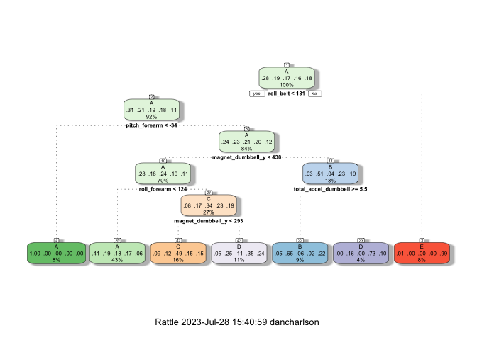

```r
model_dtrees <- train(classe~., data=trainset, method="rpart", trControl = control, tuneLength = 5)
# show a fancy tree plot, a la PDF019 in Week 3
fancyRpartPlot(model_dtrees$finalModel)
```

```r
predict_trees <- predict(model_dtrees, validset)
confmatrix_dtrees <- confusionMatrix(predict_trees, factor(validset$classe))
confmatrix_dtrees
```

```
## Confusion Matrix and Statistics
##
##           Reference
## Prediction    A    B    C    D    E
##          A 1526  462  508  451  177
##          B   27  352   30   11  136
##          C   78  145  412  134  126
##          D   37  180   76  368  168
##          E    6    0    0    0  475
##
## Overall Statistics
##
##                Accuracy : 0.5324
##                  95% CI : (0.5195, 0.5452)
##     No Information Rate : 0.2845
##     P-Value [Acc > NIR] : < 2.2e-16
##
##                   Kappa : 0.3896
##
##  Mcnemar's Test P-Value : < 2.2e-16
##
## Statistics by Class:
##
##                      Class: A Class: B Class: C Class: D Class: E
## Sensitivity            0.9116  0.30904  0.40156  0.38174  0.43900
## Specificity            0.6205  0.95702  0.90060  0.90632  0.99875
## Pos Pred Value         0.4885  0.63309  0.46034  0.44391  0.98753
## Neg Pred Value         0.9464  0.85232  0.87695  0.88212  0.88768
## Prevalence             0.2845  0.19354  0.17434  0.16381  0.18386
## Detection Rate         0.2593  0.05981  0.07001  0.06253  0.08071
## Detection Prevalence   0.5308  0.09448  0.15208  0.14087  0.08173
## Balanced Accuracy      0.7661  0.63303  0.65108  0.64403  0.71888
```

**Method #2** - next will be Random Forests - *rf*

```r
model_randfor <- train(classe~., data=trainset, method="rf", trControl = control, tuneLength = 5)
predict_randfor <- predict(model_randfor, validset)
confmatrix_randfor <- confusionMatrix(predict_randfor, factor(validset$classe))
confmatrix_randfor
```

```
## Confusion Matrix and Statistics
##
##           Reference
## Prediction    A    B    C    D    E
##          A 1672    9    0    0    0
##          B    2 1128    3    0    0
##          C    0    2 1021   15    0
##          D    0    0    2  947    0
##          E    0    0    0    2 1082
##
## Overall Statistics
##
##                Accuracy : 0.9941
##                  95% CI : (0.9917, 0.9959)
##     No Information Rate : 0.2845
##     P-Value [Acc > NIR] : < 2.2e-16
##
##                   Kappa : 0.9925
##
##  Mcnemar's Test P-Value : NA
##
## Statistics by Class:
##
##                      Class: A Class: B Class: C Class: D Class: E
## Sensitivity            0.9988   0.9903   0.9951   0.9824   1.0000
## Specificity            0.9979   0.9989   0.9965   0.9996   0.9996
## Pos Pred Value         0.9946   0.9956   0.9836   0.9979   0.9982
## Neg Pred Value         0.9995   0.9977   0.9990   0.9966   1.0000
## Prevalence             0.2845   0.1935   0.1743   0.1638   0.1839
## Detection Rate         0.2841   0.1917   0.1735   0.1609   0.1839
## Detection Prevalence   0.2856   0.1925   0.1764   0.1613   0.1842
## Balanced Accuracy      0.9983   0.9946   0.9958   0.9910   0.9998
```

**Method #3** - next will be Gradient Boosted Trees - *gbm*

```r
model_gbm <- train(classe~., data=trainset, method="gbm", trControl = control, tuneLength = 5, verbose = F)
predict_gbm <- predict(model_gbm, validset)
confmatrix_gbm <- confusionMatrix(predict_gbm, factor(validset$classe))
confmatrix_gbm
```

```
## Confusion Matrix and Statistics
##
##           Reference
## Prediction    A    B    C    D    E
##          A 1669    4    0    0    2
##          B    3 1127    8    0    1
##          C    2    8 1013   11    0
##          D    0    0    5  950    2
##          E    0    0    0    3 1077
##
## Overall Statistics
##
##                Accuracy : 0.9917
##                  95% CI : (0.989, 0.9938)
##     No Information Rate : 0.2845
##     P-Value [Acc > NIR] : < 2.2e-16
##
##                   Kappa : 0.9895
##
##  Mcnemar's Test P-Value : NA
##
## Statistics by Class:
##
##                      Class: A Class: B Class: C Class: D Class: E
## Sensitivity            0.9970   0.9895   0.9873   0.9855   0.9954
## Specificity            0.9986   0.9975   0.9957   0.9986   0.9994
## Pos Pred Value         0.9964   0.9895   0.9797   0.9927   0.9972
## Neg Pred Value         0.9988   0.9975   0.9973   0.9972   0.9990
## Prevalence             0.2845   0.1935   0.1743   0.1638   0.1839
## Detection Rate         0.2836   0.1915   0.1721   0.1614   0.1830
## Detection Prevalence   0.2846   0.1935   0.1757   0.1626   0.1835
## Balanced Accuracy      0.9978   0.9935   0.9915   0.9920   0.9974
```

**Method #4** - lastly, I will use Model-based Prediction: Linear Discriminant Analysis (LDA) - *lda*

```r
model_lda <- train(classe~., data=trainset, method="lda", trControl = control, tuneLength = 5, verbose = F)
predict_lda <- predict(model_lda, validset)
confmatrix_lda <- confusionMatrix(predict_lda, factor(validset$classe))
confmatrix_lda
```

```
## Confusion Matrix and Statistics
##
##           Reference
## Prediction    A    B    C    D    E
##          A 1373  184  104   56   41
##          B   28  719  103   54  203
##          C  141  145  665  122   72
##          D  128   41  127  691  106
##          E    4   50   27   41  660
##
## Overall Statistics
##
##                Accuracy : 0.698
##                  95% CI : (0.6861, 0.7098)
##     No Information Rate : 0.2845
##     P-Value [Acc > NIR] : < 2.2e-16
##
##                   Kappa : 0.6177
##
##  Mcnemar's Test P-Value : < 2.2e-16
##
## Statistics by Class:
##
##                      Class: A Class: B Class: C Class: D Class: E
## Sensitivity            0.8202   0.6313   0.6481   0.7168   0.6100
## Specificity            0.9086   0.9182   0.9012   0.9183   0.9746
## Pos Pred Value         0.7810   0.6495   0.5808   0.6322   0.8440
## Neg Pred Value         0.9271   0.9121   0.9238   0.9430   0.9173
## Prevalence             0.2845   0.1935   0.1743   0.1638   0.1839
## Detection Rate         0.2333   0.1222   0.1130   0.1174   0.1121
## Detection Prevalence   0.2987   0.1881   0.1946   0.1857   0.1329
## Balanced Accuracy      0.8644   0.7748   0.7747   0.8176   0.7923
```

## Results on Training (Validation) data sets

I will now apply the Random Forest model on the Test Data.

```r
predict_randfor_testdata <- predict(model_randfor, test_data_cleaned)
predict_randfor_testdata
```

```
##  [1] B A B A A E D B A A B C B A E E A B B B
## Levels: A B C D E
```

(These are the values I will submit to the Quiz.)

## Appendix

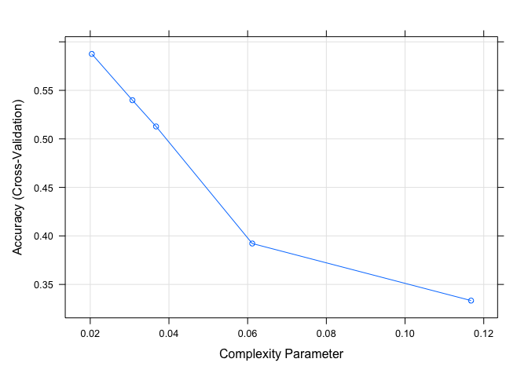

```r
plot(model_dtrees)
```

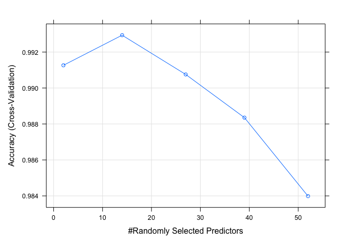

```r
plot(model_randfor)
```

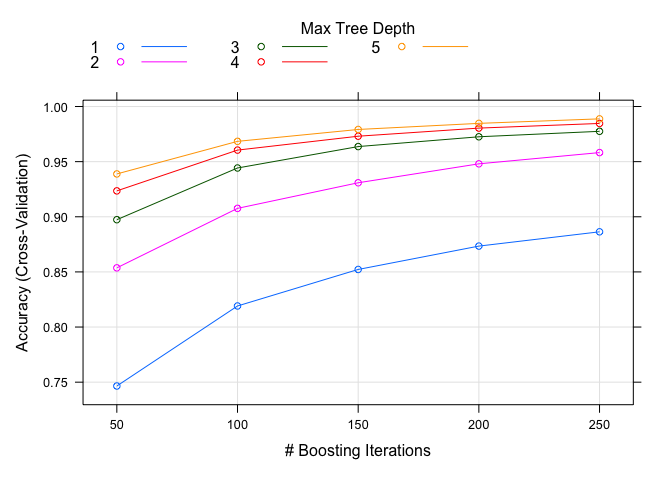

```r
plot(model_gbm)
```

```r
# plot(model_lda) - this one fails "no tuning parameters"
```

**END**